# Introduction to Statistical Learning part 8: model selection for regression

Steven Troxler

January 7, 2016

Welcome to the eighth post in my series on [An Introduction to Statistical Learning with Applications in R](http://www-bcf.usc.edu/~gareth/ISL/). In the last two posts, we saw some simple examples of cross-validation and the bootstrap. In this post, we’re going to look at model selection for linear models using a few different methods, including cross-validation.

## The `ISLR::Hitters` dataset

The `Hitters` dataset from the `ISLR` package contains data on major league baseball hitters in 1986 and 1987. Let’s take a quick look:

```r
hitters <- tbl_df(ISLR::Hitters)
hitters
```

```
#> Source: local data frame [322 x 20]
#>
#>    AtBat  Hits HmRun  Runs   RBI Walks Years CAtBat CHits CHmRun CRuns
#>    (int) (int) (int) (int) (int) (int) (int)  (int) (int)  (int) (int)
#> 1    293    66     1    30    29    14     1    293    66      1    30
#> 2    315    81     7    24    38    39    14   3449   835     69   321
#> 3    479   130    18    66    72    76     3   1624   457     63   224
#> 4    496   141    20    65    78    37    11   5628  1575    225   828
#> 5    321    87    10    39    42    30     2    396   101     12    48
#> 6    594   169     4    74    51    35    11   4408  1133     19   501
#> 7    185    37     1    23     8    21     2    214    42      1    30
#> 8    298    73     0    24    24     7     3    509   108      0    41
#> 9    323    81     6    26    32     8     2    341    86      6    32
#> 10   401    92    17    49    66    65    13   5206  1332    253   784
#> ..   ...   ...   ...   ...   ...   ...   ...    ...   ...    ...   ...
#> Variables not shown: CRBI (int), CWalks (int), League (fctr), Division
#>   (fctr), PutOuts (int), Assists (int), Errors (int), Salary (dbl),
#>   NewLeague (fctr)
```

We’ll try to predict player salaries. Let’s look at a summary and a histogram of salary:

```r
summary(hitters$Salary)
```

```
#>    Min. 1st Qu.  Median    Mean 3rd Qu.    Max.    NA's
#>    67.5   190.0   425.0   535.9   750.0  2460.0      59
```

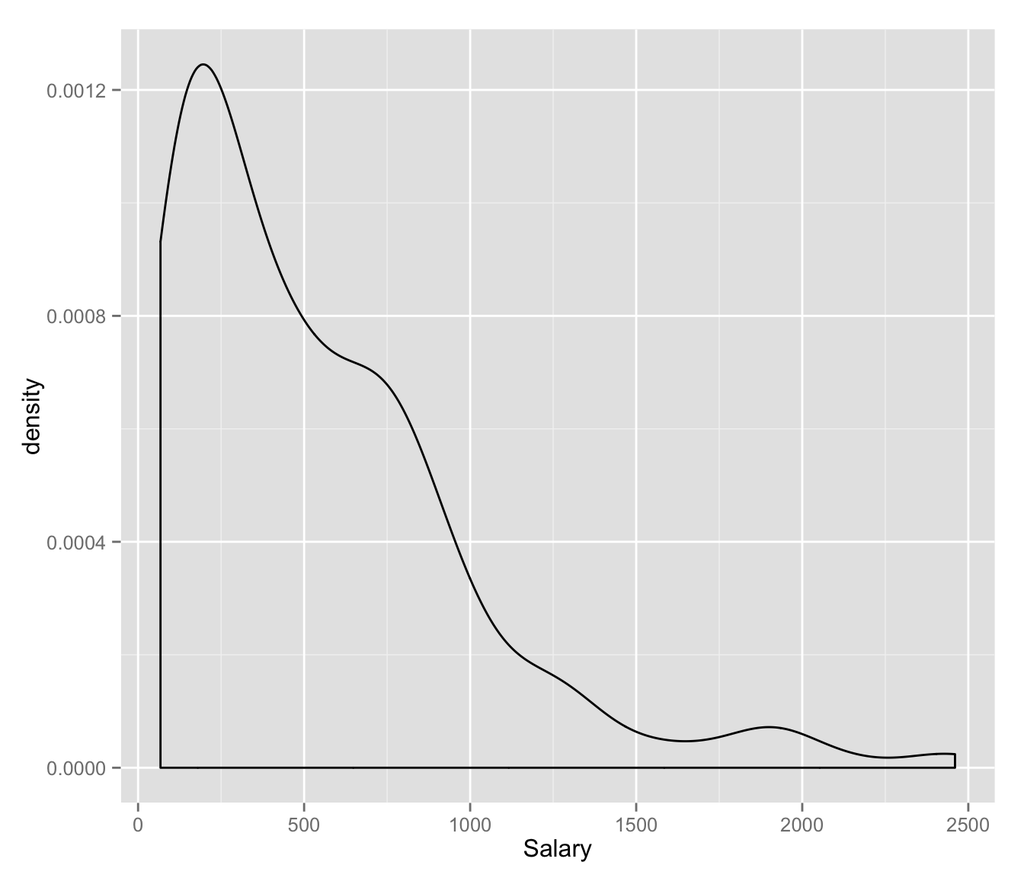

```r
ggplot(hitters, aes(x=Salary)) + geom_density()
```

Unfortunately, there are quite a few missing values here, so we’ll remove them.

```r
hitters <- na.omit(hitters)
```

## Best subset selection

Best subset selection is an exhaustive-search approach to linear models. It only works when the number of covariates is fairly small, since the number of possible linear models grows exponentially with the number of variables. But if we have plenty of data with only a few variables, it’s not a bad way of picking a well-fitting model.

The `leaps` library (you may need to run `install.packages("leaps")` before running the code) has a function `regsubsets` for doing best-subset selection. Let’s take a look:

```r
library(leaps)
best_subset_info <- regsubsets(Salary~., data=hitters, nvmax=19)
best_subset_summary <- summary(best_subset_info)
best_subset_summary
```

```
#> Subset selection object
#> Call: regsubsets.formula(Salary ~ ., data = hitters, nvmax = 19)
#> 19 Variables  (and intercept)
#>            Forced in Forced out
#> AtBat          FALSE      FALSE
#> Hits           FALSE      FALSE
#> HmRun          FALSE      FALSE
#> Runs           FALSE      FALSE
#> RBI            FALSE      FALSE
#> Walks          FALSE      FALSE
#> Years          FALSE      FALSE
#> CAtBat         FALSE      FALSE
#> CHits          FALSE      FALSE
#> CHmRun         FALSE      FALSE
#> CRuns          FALSE      FALSE
#> CRBI           FALSE      FALSE
#> CWalks         FALSE      FALSE
#> LeagueN        FALSE      FALSE
#> DivisionW      FALSE      FALSE
#> PutOuts        FALSE      FALSE
#> Assists        FALSE      FALSE
#> Errors         FALSE      FALSE
#> NewLeagueN     FALSE      FALSE
#> 1 subsets of each size up to 19
#> Selection Algorithm: exhaustive
#>           AtBat Hits HmRun Runs RBI Walks Years CAtBat CHits CHmRun CRuns
#> 1  ( 1 )  " "   " "  " "   " "  " " " "   " "   " "    " "   " "    " "
#> 2  ( 1 )  " "   "*"  " "   " "  " " " "   " "   " "    " "   " "    " "
#> 3  ( 1 )  " "   "*"  " "   " "  " " " "   " "   " "    " "   " "    " "
#> 4  ( 1 )  " "   "*"  " "   " "  " " " "   " "   " "    " "   " "    " "
#> 5  ( 1 )  "*"   "*"  " "   " "  " " " "   " "   " "    " "   " "    " "
#> 6  ( 1 )  "*"   "*"  " "   " "  " " "*"   " "   " "    " "   " "    " "
#> 7  ( 1 )  " "   "*"  " "   " "  " " "*"   " "   "*"    "*"   "*"    " "
#> 8  ( 1 )  "*"   "*"  " "   " "  " " "*"   " "   " "    " "   "*"    "*"
#> 9  ( 1 )  "*"   "*"  " "   " "  " " "*"   " "   "*"    " "   " "    "*"
#> 10  ( 1 ) "*"   "*"  " "   " "  " " "*"   " "   "*"    " "   " "    "*"
#> 11  ( 1 ) "*"   "*"  " "   " "  " " "*"   " "   "*"    " "   " "    "*"
#> 12  ( 1 ) "*"   "*"  " "   "*"  " " "*"   " "   "*"    " "   " "    "*"
#> 13  ( 1 ) "*"   "*"  " "   "*"  " " "*"   " "   "*"    " "   " "    "*"
#> 14  ( 1 ) "*"   "*"  "*"   "*"  " " "*"   " "   "*"    " "   " "    "*"
```

[output cut: 10 more lines]

```
#> 5  ( 1 )  "*"  " "    " "     "*"       "*"     " "     " "    " "
#> 6  ( 1 )  "*"  " "    " "     "*"       "*"     " "     " "    " "
#> 7  ( 1 )  " "  " "    " "     "*"       "*"     " "     " "    " "
#> 8  ( 1 )  " "  "*"    " "     "*"       "*"     " "     " "    " "
#> 9  ( 1 )  "*"  "*"    " "     "*"       "*"     " "     " "    " "
#> 10  ( 1 ) "*"  "*"    " "     "*"       "*"     "*"     " "    " "
#> 11  ( 1 ) "*"  "*"    "*"     "*"       "*"     "*"     " "    " "
#> 12  ( 1 ) "*"  "*"    "*"     "*"       "*"     "*"     " "    " "
#> 13  ( 1 ) "*"  "*"    "*"     "*"       "*"     "*"     "*"    " "
#> 14  ( 1 ) "*"  "*"    "*"     "*"       "*"     "*"     "*"    " "
#> 15  ( 1 ) "*"  "*"    "*"     "*"       "*"     "*"     "*"    " "
#> 16  ( 1 ) "*"  "*"    "*"     "*"       "*"     "*"     "*"    " "
#> 17  ( 1 ) "*"  "*"    "*"     "*"       "*"     "*"     "*"    "*"
#> 18  ( 1 ) "*"  "*"    "*"     "*"       "*"     "*"     "*"    "*"
#> 19  ( 1 ) "*"  "*"    "*"     "*"       "*"     "*"     "*"    "*"
```

The fit is quite fast with a small number of variables, likely because the work of forming `X^T X` and `X^T Y` can be reused by cleverly slicing matrices. The output of summary is telling us what the best variables are for each subset size: the columns that have ’*’s for each row are the variables included in the best model of that size.

The summary has a number of entries:

```r
names(best_subset_summary)
```

```
#> [1] "which"  "rsq"    "rss"    "adjr2"  "cp"     "bic"    "outmat" "obj"
```

In the interests of speed, we’re going to use [Mallow’s Cp statistic](https://en.wikipedia.org/wiki/Mallows%27s_Cp), which is closely related to the AIC statistic, to pick the best model.

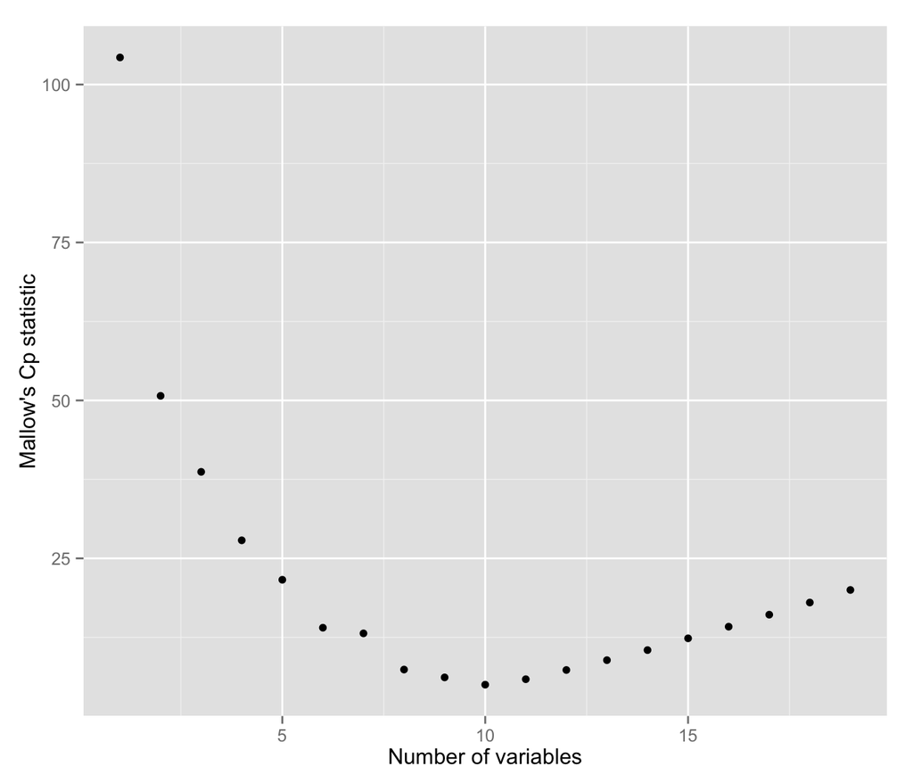

```r
qplot(1:19, best_subset_summary$cp,
      xlab = "Number of variables", ylab = "Mallow's Cp statistic")
```

```r
which.min(best_subset_summary$cp)
```

```
#> [1] 10
```

The smallest value of Mallow’s Cp corresponds to the best expected predictive accuracy, so it looks like the 10 variable model may do best.

There’s also a nice `plot` method on the best subsets output, which makes a white/black plot similar to what we get by printing the summary, and lets us order the y axis by various measures of fit (the default is `bic`, but we’ll tell it to use `cp`)

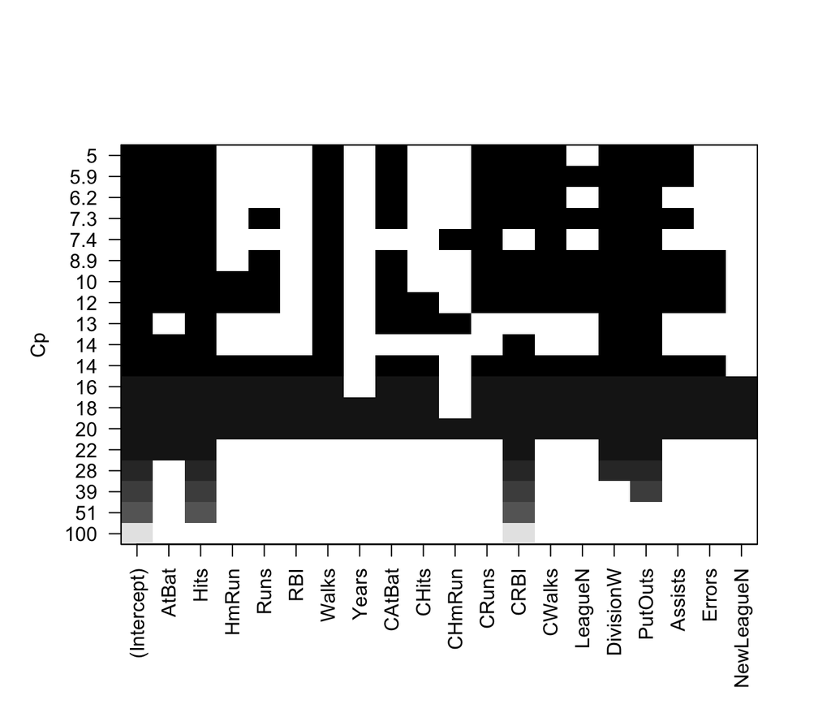

```r
plot(best_subset_info, scale='Cp')
```

### A warning about the analysis we just did

I’d like to point out a possible issue with the way we used the Cp statistic: there were `choose(19, 10)` or `92378` possible models with 10 variables, and we picked the best one. So Mallow’s Cp statistic - which doesn’t know that we’re data snooping by picking the best of many models - may be biased toward more complex models.

If this were a real-life data science project, we would want to confirm via a safer method like cross-validation, and we wouldn’t be surprised if the best model had fewer variables than our Cp-statistic-based analysis suggested using. Later in this post, we’ll look at using a validation set for model selection.

## Forward Stepwise Selection

The best-subsets selection method we used in the preceding section searches over all possible models for each subset size. This won’t scale well at all if we have many variables: it did fine with 19, but if we have dozens or more, we’ll be in a lot of trouble because the number of models scales exponentially with the number of columns in $X$.

Stepwise selection is a greedy approach to getting a round this: instead of hunting through all possible models, we just add variables one at a time, at each step adding the variable that most improves the model fit. The number of decisions we have to make is now just linear in the number of columns of $X$ - one variable at a time - and the total number of models we need to evaluate scales roughly like the square of the number of variables in $X.$ If we have hundreds of variables, this is still quite manageable.

The `leaps` package allows forward selection using the same `regsubsets` function. To use forward selection rather than best subset, we just add the `method = "forward"` argument:

```r
fwd_sel_info <- regsubsets(Salary~., data=hitters, nvmax=19, method="forward")
summary(fwd_sel_info)
```

```
#> Subset selection object
#> Call: regsubsets.formula(Salary ~ ., data = hitters, nvmax = 19, method = "forward")
#> 19 Variables  (and intercept)
#>            Forced in Forced out
#> AtBat          FALSE      FALSE
#> Hits           FALSE      FALSE
#> HmRun          FALSE      FALSE
#> Runs           FALSE      FALSE
#> RBI            FALSE      FALSE
#> Walks          FALSE      FALSE
#> Years          FALSE      FALSE
#> CAtBat         FALSE      FALSE
#> CHits          FALSE      FALSE
#> CHmRun         FALSE      FALSE
#> CRuns          FALSE      FALSE
#> CRBI           FALSE      FALSE
#> CWalks         FALSE      FALSE
#> LeagueN        FALSE      FALSE
#> DivisionW      FALSE      FALSE
#> PutOuts        FALSE      FALSE
#> Assists        FALSE      FALSE
#> Errors         FALSE      FALSE
#> NewLeagueN     FALSE      FALSE
#> 1 subsets of each size up to 19
#> Selection Algorithm: forward
#>           AtBat Hits HmRun Runs RBI Walks Years CAtBat CHits CHmRun CRuns
#> 1  ( 1 )  " "   " "  " "   " "  " " " "   " "   " "    " "   " "    " "
#> 2  ( 1 )  " "   "*"  " "   " "  " " " "   " "   " "    " "   " "    " "
#> 3  ( 1 )  " "   "*"  " "   " "  " " " "   " "   " "    " "   " "    " "
#> 4  ( 1 )  " "   "*"  " "   " "  " " " "   " "   " "    " "   " "    " "
#> 5  ( 1 )  "*"   "*"  " "   " "  " " " "   " "   " "    " "   " "    " "
#> 6  ( 1 )  "*"   "*"  " "   " "  " " "*"   " "   " "    " "   " "    " "
#> 7  ( 1 )  "*"   "*"  " "   " "  " " "*"   " "   " "    " "   " "    " "
#> 8  ( 1 )  "*"   "*"  " "   " "  " " "*"   " "   " "    " "   " "    "*"
#> 9  ( 1 )  "*"   "*"  " "   " "  " " "*"   " "   "*"    " "   " "    "*"
#> 10  ( 1 ) "*"   "*"  " "   " "  " " "*"   " "   "*"    " "   " "    "*"
#> 11  ( 1 ) "*"   "*"  " "   " "  " " "*"   " "   "*"    " "   " "    "*"
#> 12  ( 1 ) "*"   "*"  " "   "*"  " " "*"   " "   "*"    " "   " "    "*"
#> 13  ( 1 ) "*"   "*"  " "   "*"  " " "*"   " "   "*"    " "   " "    "*"
#> 14  ( 1 ) "*"   "*"  "*"   "*"  " " "*"   " "   "*"    " "   " "    "*"
```

[output cut: 10 more lines]

```
#> 5  ( 1 )  "*"  " "    " "     "*"       "*"     " "     " "    " "
#> 6  ( 1 )  "*"  " "    " "     "*"       "*"     " "     " "    " "
#> 7  ( 1 )  "*"  "*"    " "     "*"       "*"     " "     " "    " "
#> 8  ( 1 )  "*"  "*"    " "     "*"       "*"     " "     " "    " "
#> 9  ( 1 )  "*"  "*"    " "     "*"       "*"     " "     " "    " "
#> 10  ( 1 ) "*"  "*"    " "     "*"       "*"     "*"     " "    " "
#> 11  ( 1 ) "*"  "*"    "*"     "*"       "*"     "*"     " "    " "
#> 12  ( 1 ) "*"  "*"    "*"     "*"       "*"     "*"     " "    " "
#> 13  ( 1 ) "*"  "*"    "*"     "*"       "*"     "*"     "*"    " "
#> 14  ( 1 ) "*"  "*"    "*"     "*"       "*"     "*"     "*"    " "
#> 15  ( 1 ) "*"  "*"    "*"     "*"       "*"     "*"     "*"    " "
#> 16  ( 1 ) "*"  "*"    "*"     "*"       "*"     "*"     "*"    " "
#> 17  ( 1 ) "*"  "*"    "*"     "*"       "*"     "*"     "*"    "*"
#> 18  ( 1 ) "*"  "*"    "*"     "*"       "*"     "*"     "*"    "*"
#> 19  ( 1 ) "*"  "*"    "*"     "*"       "*"     "*"     "*"    "*"
```

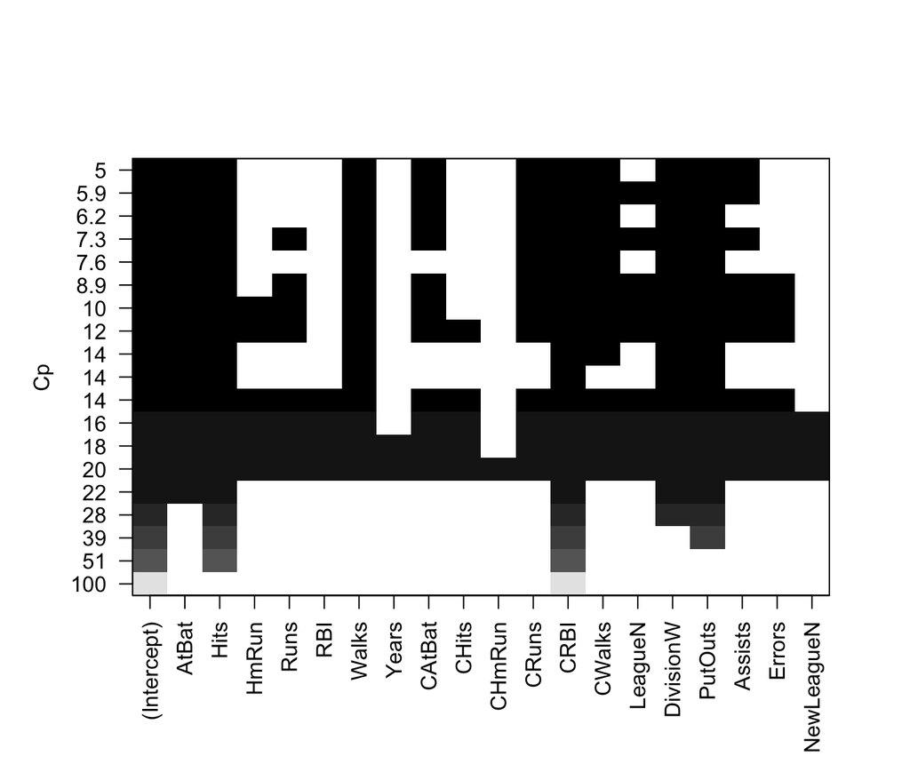

```r
plot(fwd_sel_info, scale="Cp")
```

The same warning we had as with best subset selection - that the Cp statistic may be misleading - applies here. But because the forward selection searches through fewer models, the problem isn’t quite as severe here as it was for best subset selection.

## Using a validation set for model selection

Keeping in mind all the reasons above why we might not trust the Cp statistic to give us a good model choice, let’s try working with a training / test set split:

```r
set.seed(255)
hitters_train <- sample_frac(hitters, 0.666)
hitters_test <- setdiff(hitters, hitters_train)
```

Now as we fit models, we can collect the errors on the test set, which gives us a very good estimate - which is robust to choosing best models, unlike the Cp statistic - of how well the model actually predicts salaries.

There’s no `predict` function for the output of a `regsubsets` fit. But we can use the `coef` function to get a `betahat` that includes variable names, and there’s a handy built-in function `model.matrix` for getting a covariate matrix given a data frame and a model formula. When we make our predictions, have to slice this matrix using the variable names to match `betahat`:

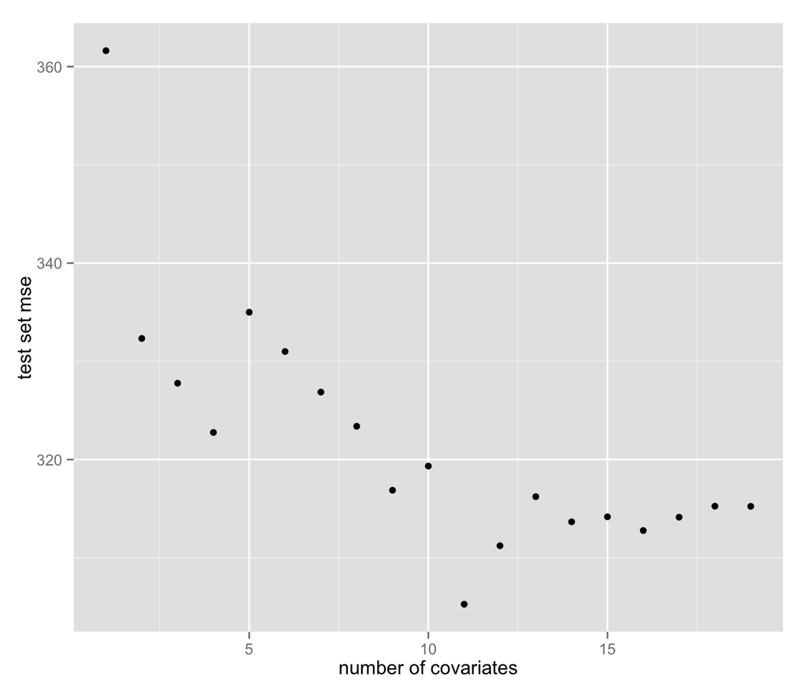

```r
test_err <- rep(NA, 19)
train_fwd_sel_info = regsubsets(Salary~., data=hitters_train,
                                nvmax=19, method="forward")
x_test <- model.matrix(Salary~., data=hitters_test)
y_test <- hitters_test$Salary
for (nvar in 1:19) {
  betahat <- coef(train_fwd_sel_info, id=nvar)
  yhat <- x_test[, names(betahat)] %*% betahat
  test_err[nvar] <- mean((y_test - yhat) ** 2)
}
qplot(1:19, sqrt(test_err), xlab = "number of covariates", ylab="test set mse")
```

```r
which.min(test_err)
```

```
#> [1] 11
```

Surprisingly (to me), on this split the test error was minimized with 11 variables, although it’s much less smooth than the plots of the Cp statistic (this is typical, since it comes from random data).

If we wanted to regularly make predictions from `regsubsets` models, it would be handy to have a `predict` function that works. To finish up this part of the post with some programming practice, let’s write one:

```r
predict.regsubsets <- function(regsub, nvar, df) {
  # extract the formula. We have an underscore in the var name so that
  # we don't confuse this variable with the stats::formula function.
  formula_ <- as.formula(regsub$call[[2]])
  x <- model.matrix(formula_, data=df)
  betahat = coef(regsub, id=nvar)
  # remember, the last line is the return value, we don't need a
  # return statement in R
  x[,names(betahat)] %*% betahat
}
```

## Cross-validation

Our last topic for today is to use cross-validation for the prediction problem. We’ve already seen cross-validation before: it’s similar to using a training / test set split, but we split the data repeatedly and use every data point in one test set. It’s slower than using a single training / test set split, but because we use more data we get better estimates of model accuracy.

```r
folds <- sample(rep(1:10, length=nrow(hitters)))
folds[1:20]
```

```
#>  [1]  1  3  7  6  8 10  7  3  2  5  1  4  7  2  6  3 10  3  6  8
```

Next, we run through the different model sizes and record errors as we did when using a training and test set. But this time we also have to loop over the cross validation folds, so our code is a double loop.

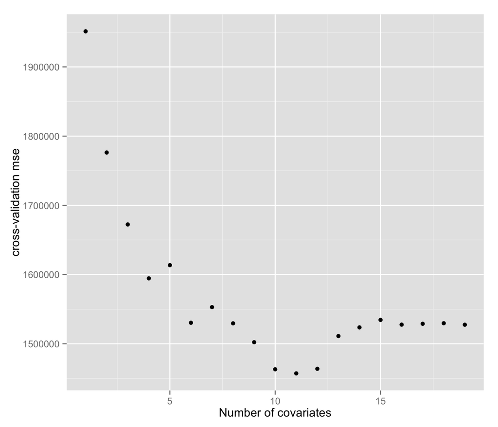

```r
cv_errors <- rep(0, 19)
for (fold in 1:10) {
  h_test = hitters[folds == fold,]
  h_train = hitters[folds != fold,]
  fwd_sel_info = regsubsets(Salary~., data=h_train,
                            nvmax=19, method="forward")
  y_test = h_test$Salary
  for (nvar in 1:19) {
    yhat <- predict.regsubsets(fwd_sel_info, nvar, h_test)
    cv_errors[nvar] = cv_errors[nvar] + (
      length(yhat) / length(hitters) * mean((yhat - y_test) ** 2)
    )
  }
}
qplot(1:19, cv_errors, xlab = "Number of covariates", ylab="cross-validation mse")
```

Note that the error is still minimized around a model size of 11, and the error estimates are noticeably smoother than they were when we used a single training and test set split.

## Next Post

In our next post, we’ll look at applying model selection methods to working with regularized linear models. We’ll look at ridge regression and the lasso, which are variations on least-squares which work for very large models.